# Indo-Swiss Research Database - Analysis log

# How has the composition of research keywords changed over 25 years

We examine all the papers in two 5 year periods - 2000-2004 and 2020-2024. In case author keywords are not provided for a paper, we have used the keywords that are generated by Web of Science or Scopus. Below are visualisations of the most common keywords using a word cloud.

## Research keywords in the period of 2000 - 2004

```
## There are 595 publications with keywords in the 5 year period between 2000 and 2004
```

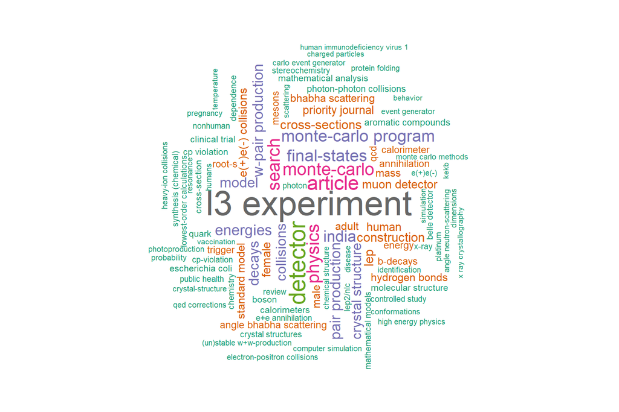

## Research in the period 2020 to 2024

```
## There are 7312 publications with keywords in the 5 year period between 2020 and 2024
```

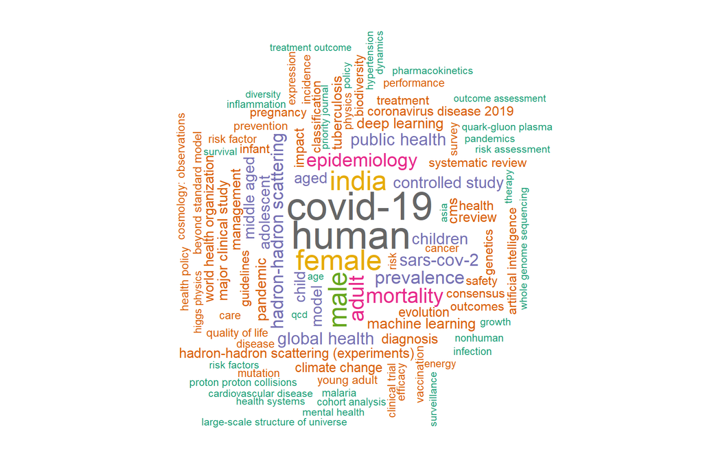

# Identifying the institutions conducting research

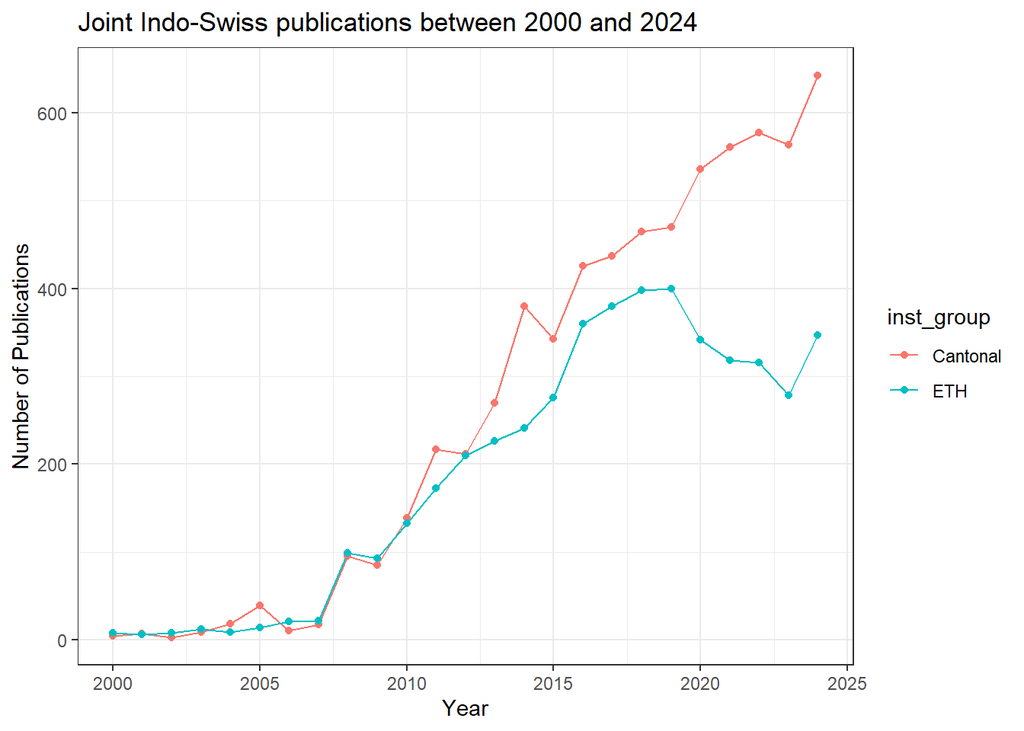

[^1]: Data of total number of entries in Scopus by year is gotten from Mike Thelwall, Pardeep Sud; Scopus 1900–2020: Growth in articles, abstracts, countries, fields, and journals. Quantitative Science Studies 2022; 3 (1): 37–50. doi: https://doi.org/10.1162/qss_a_00177